# Coursework Report

*N* removed NAs: 2

*N* removed <18: 17

*N* total clean: 129

| Group | *N* | *M*<sub>age</sub> | *M*<sub>rating</sub> |
| --- | --- | --- | --- |
| Control | 59 | 21.27 | 5.25 |
| Experim | 70 | 20.99 | 6.14 |

**Main analysis results**

*t*(127) = -6.76, *p* < .001

# Coursework Report

Analysing Data, Spring 2020

# Methods

## Participants

*Table 1* A Summary of Participant Demographics split up by Colour

| Condition | Count | *M*<sub>age</sub> | *SD*<sub>age</sub> |
| --- | --- | --- | --- |
| White | 54 | 21.61 | 2.10 |
| Red | 59 | 21.54 | 1.98 |

## Design

Within our experiment, our conceptual hypothesis was that does colour unintentionally affect people’s perception of attractiveness. We tested this using a factor variable with two levels to randomly allocate the participants into two colour conditions; the control group saw the photograph of a man with a white background (*n* = 54) and the experimental group saw the same photograph but with a red one (*n* = 59). After they view the photo, ratings of attractiveness were measured using three questions based on how attractive (1 item), pleasant they were (1 item) and whether they would find them attractive in person (1 item). The three items used a 9-point scale (1 = *“Not attractive”* to 9 = *Very attractive"*). As a result, our operational hypothesis was that females that viewed the photograph of the moderately attractive man on the red background would rate him more attractive on the three rating scales in contrast to participants that saw the same man on a white background. To test this hypothesis, we will carry out a statistical *t*-test to determine whether the difference in mean scores of attractiveness in each colour condition is significant.

# Results

*Table 2* A Summary of Mean Attractiveness ratings split up by Colour

[output not shown]

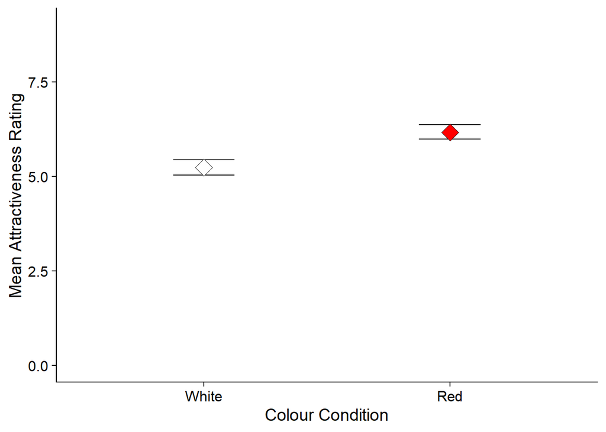

# Discussion

In comparison to other studies regarding colour on attractiveness there were contrasting results. Our results were consistent with the first experiment in the original Elliot et al (2010) study; the red condition produced a higher attractiveness rating than the white condition. This perhaps suggests that our results may be high in reliability and validity as we used the same materials and design as used within the original experiment. Furthermore, Elliot et al (2013) later conducted another experiment revisiting the red effect but on a different sample population - “culturally isolated individuals living in a traditional small society” (Elliot et al., 2013, pg. 167). He again found a red-attraction link as men who saw the female with the red background rated her as more attractive than those who saw the female on the blue background. This thus shows the red effect isn’t culturally specific; it is universal and therefore innate. However, these results have been contradicted. Peperkoorn et al (2016) found no effect of the colour red on attractiveness on both Dutch and American males. This is evident in experiment 1; “Participants assigned to the white condition (M 1⁄4 7.59, SD 1⁄4 1.32) rated the woman as more attractive compared with those in the red (M 1⁄4 7.06, SD 1⁄4 1.44).” (Peperkoorn et al, 2016, pg. 6). This is inconsistent with our findings, yet their design differed to ours; participants viewed a photograph of a female in either a red, black or white t-shirt, combined with a specific scenario. It could be argued that these differences may account for the null effects. Yet, in Hesslinger et al’s (2015) first experiment, they also found no red-attraction link even though they used a larger sample of participants; they found a small insignificant difference between the mean ratings. As the same materials and a similar design was used, this suggests that our results may be flawed.

Although our results suggest that the colour red unintentionally affects attractiveness, our study has clear limitations. A lab environment provides strong internal validity; the manipulation of colour varied the attractiveness ratings. However, lab studies lack ecological validity thus there may be another intervening factor that may be superior to colour that also affects female perceptions of male attractiveness. For instance, Hesslinger et al (2015, pg. 1147) found that “Men wearing formal suits were perceived as being more attractive than men wearing casual sportswear”, suggesting that male attire may have a greater influence on attractiveness ratings than colour. Our methodology was also flawed; a between-subjects design using different females for each condition creates individual differences between the two groups. For example, some females may have a preference for males with blonde hair, whilst other females may find brunettes more attractive. Consequently, this may have impacted our final results. Additionally, the use of rating scales limits our findings. Rating scales can be interpreted differently amongst participants; a female may view a rating of 8 as attractive whilst another female may feel the same way, yet only give a score of 6. This may account for why females in the red condition perceived the male as more attractive, limiting our results. As our replication was identical to Elliot et al’s (2000) study, the participants used were all exclusively undergraduates. Therefore, we cannot generalise our findings as they aren’t representative to all ages.

As a result, based on our findings, future research could perhaps measure the red-attractiveness link using physiological indicators, such as heart rate or skin conductance, rather than rating scales. This may produce more accurate findings. Chanhizi et al (2006) found females to be proficient at recognising changes in blood flow in the face, therefore researchers could also manipulate the colouration of the male’s face, rather than the background, and measure whether this affects attractiveness - and produces a physiological response. Additionally, future studies could manipulate the time allowed to view the photograph, as numerous studies have limited the time to 5 seconds (Elliot et al., 2008, 2010; Hesslinger, Goldbach & Carbon, 2015; Pazda et al., 2014; Schwartz & Singer, 2013). Could a longer time to view the photo affect perceptions of attractiveness? Young (2015) found that when presented with 40 unattractive and attractive female faces, the red effect only appeared for the attractive faces. Thus, experimenting using a diverse range of models could be an interesting area for future research. Alternatively, instead of using a between-subjects design, researchers could use a mixed design; a combination of both between-subjects and within-subjects designs may be beneficial (Peperkoorn, 2016).

In conclusion, our results show a significant red-effect; men viewed on a red background appear to be more attractive than those viewed on white background. More research surrounding this area is essential, yet our study overall suggests that the red-attractiveness link may be primitive and isn’t just a “ubiquitous perceptual stimulus” but holds value in that it can “impact individuals’ psychological functioning” (Elliot et al., 2010, pg. 412).

# References

Elliot, A. J., Kayser, D. N., Greitemeyer, T., Lichtenfeld, S., Gramzow, R. H., Maier, M. A., & Liu, H. (2010). Red, rank, and romance in women viewing men. Journal of Experimental Psychology: General, 139(3), 399–417.

Elliot, A. J., Tracy, J. L., Pazda, A. D., & Beall, A. T. (2013). Red enhances womens attractiveness to men: First evidence suggesting universality. Journal of Experimental Social Psychology, 49(1), 165–168. doi: 10.1016/j.jesp.2012.07.017

Hesslinger, V. M., Goldbach, L., & Carbon, C.-C. (2015). Men in red: A reexamination of the red-attractiveness effect. Psychonomic Bulletin & Review, 22(4), 1142–1148. doi: 10.3758/s13423-015-0866-8

Pazda, A. D., Prokop, P., & Elliot, A. J. (2014). Red and Romantic Rivalry. Personality and Social Psychology Bulletin, 40(10), 1260–1269. doi: 10.1177/0146167214539709

Peperkoorn, L. S., Roberts, S. C., & Pollet, T. V. (2016). Revisiting the red effect on attractiveness and sexual receptivity: No effect of the color red on human mate preferences. Evolutionary Psychology, 14(4), 1–13.

Schwarz, S., & Singer, M. (2013). Romantic red revisited: Red enhances mens attraction to young, but not menopausal women. Journal of Experimental Social Psychology, 49(1), 161–164. doi: 10.1016/j.jesp.2012.08.004

Young, S. G. (2015). The effect of red on male perceptions of female attractiveness: Moderation by baseline attractiveness of female faces. European Journal of Social Psychology, 45(2), 146–151. doi: 10.1002/ejsp.2098